# Informe Primer Semestre 2021

Matemáticas

Claudio Rojas. Director Académico

2021-09-02

## 0.1 Presentación

El presente informe tiene como objetivo revisar el trabajo del sector, a través de información que sistematiza los resultados académicos del I semestre y recoge lo proyectado para el II semestre del presente año. Además, consideran las definiciones claves que tenemos como colegio pero también como institución de la Compañía de Jesús.

Los apartados del informe son:

- Definiciones Claves
- Informe de Notas
- Metas de Aprendizaje.
- Propuestas de Evaluación II Semestre.
- Sugerencias para la planificación de las unidades 2 y 3.

Cada una de las partes de informe incluye sugerencias que buscan orientar la reflexión y práctica del sector para poder realizar los ajustes que sean necesarios para el logro de los aprendzajes que sean definidos.

## 0.2 Definiciones Claves

Les recuerdo tener presente las definiciones claves tanto a nivel de red ignaciana como interna que deben siempre orientar nuestro trabajo académico.

### 0.2.1 Envío 3 Planificación Estratégica de los colegios Jesuitas

Asegurar que los 10 colegios y escuelas jesuitas desarrollen las prácticas y procesos necesarios para ofrecer la excelencia académica propia de una comprensión ignaciana de la educación de calidad.

### 0.2.2 Nuestra Definición de Calidad

Nosotros, como comunidad sanjavierina, entendemos por educación de calidad todo aprendizaje que nos lleva a descubrir y desarrollar nuestras capacidades de manera integral, formándonos como personas competentes, conscientes, comprometidas, compasivas y creativas, para así conocer y amar más y mejor a Jesucristo, sirviendo a nuestros hermanos en los diversos contextos sociales.

### 0.2.3 Nuestro Foco de Mejora

Fortalecer la propuesta curricular, con una didáctica renovada, bajo el Paradigma Pedagógico Ignaciano.

## 0.3 Informe de Notas

El informe de notas contiene la siguiente información:

- Tabla de Resumen de las notas por nivel.
- Notas de 1º básico a IVº medio.
- Distribución por nivel de logro.

En el caso de los resultados, les sugiero analizar:

- Los promedios finales obtenidos por cada nivel
- Cantidad de estudiantes que están en cada nivel de logro.
- Las diferencias de resultados entre hombres y mujeres.

### 0.3.1 Tabla Resumen de Notas:

Esta tabla incluye la siguiente información de la asignatura por nivel:

- Promedio de la asignatura.
- Nota Mínima.
- Mediana.
- Nota Máxima.

[output not shown]

### 0.3.2 Notas de 1º básico a IVº medio

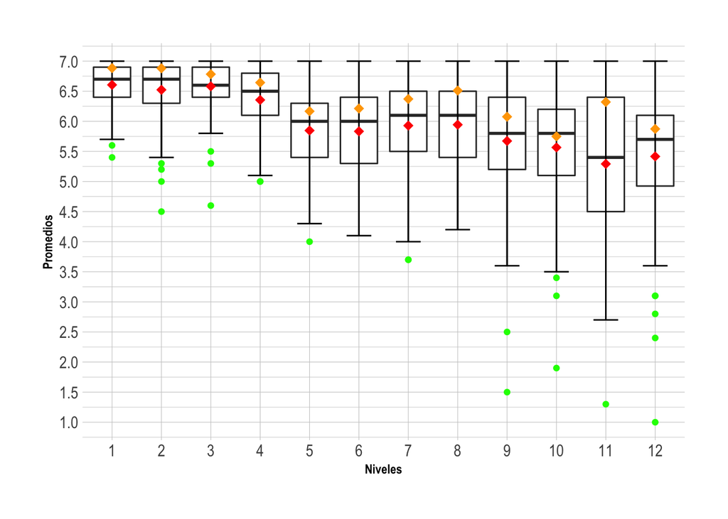

### 0.3.3 Distribución de Estudiantes por Niveles de Logro y diferenciado por Sexo.

#### 0.3.3.1 Primeros Básicos

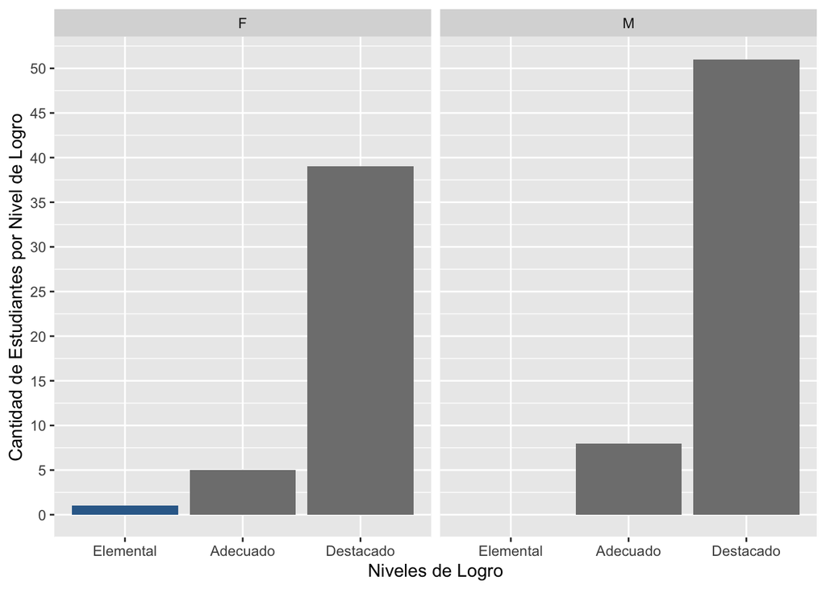

#### 0.3.3.2 Segundos Básicos

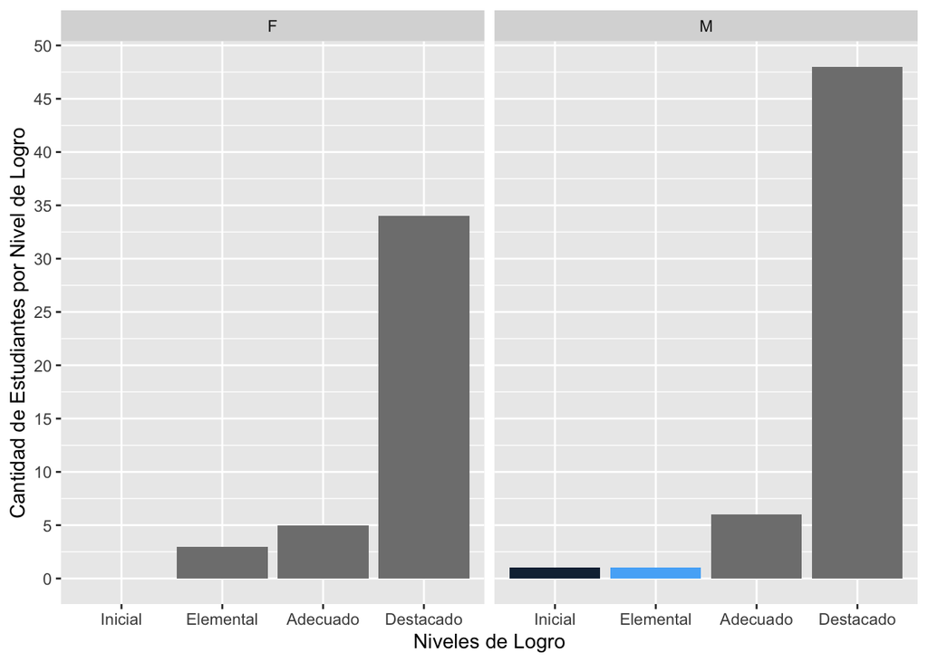

#### 0.3.3.3 Terceros Básicos

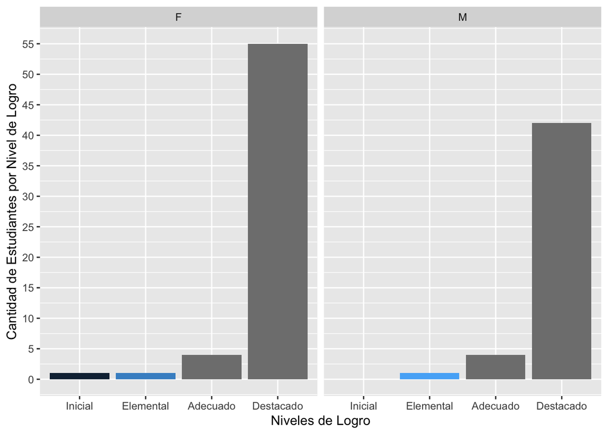

#### 0.3.3.4 Cuartos Básicos

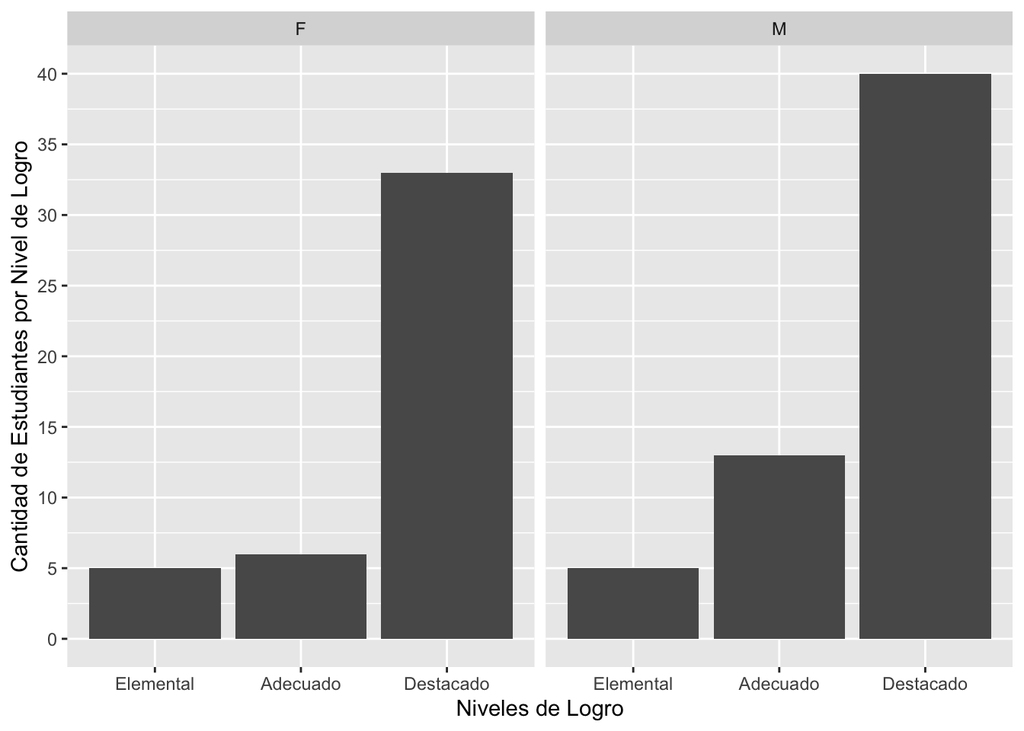

#### 0.3.3.5 Quintos Básicos

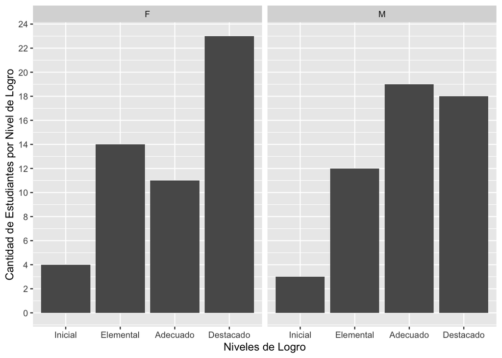

#### 0.3.3.6 Sextos Básicos

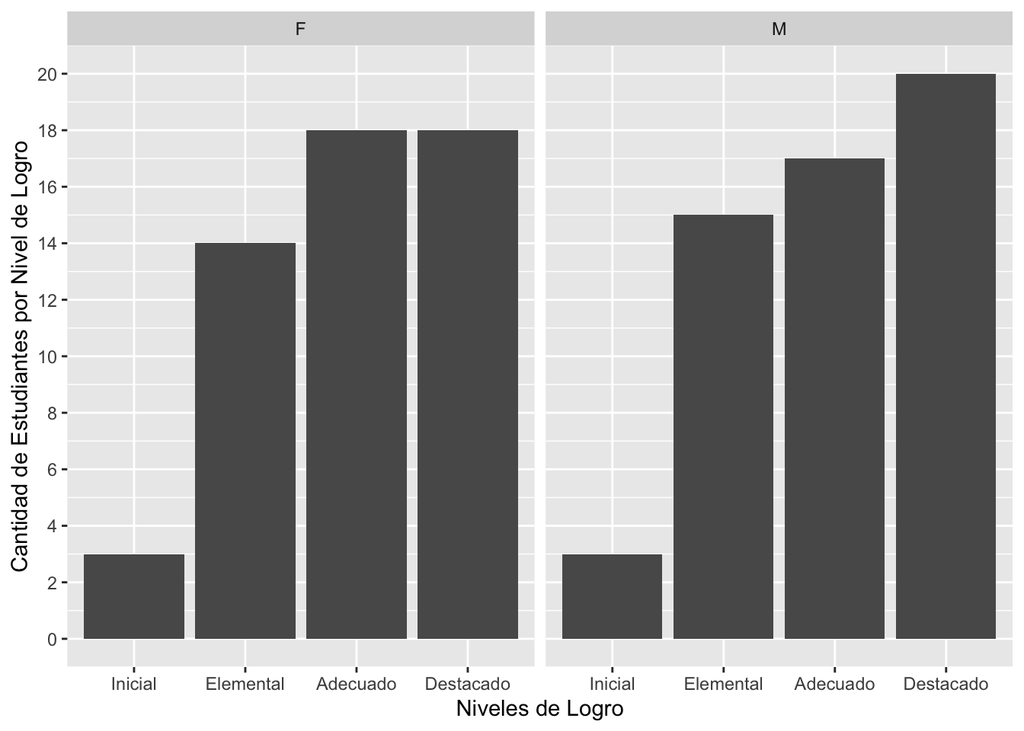

#### 0.3.3.7 Séptimos Básicos

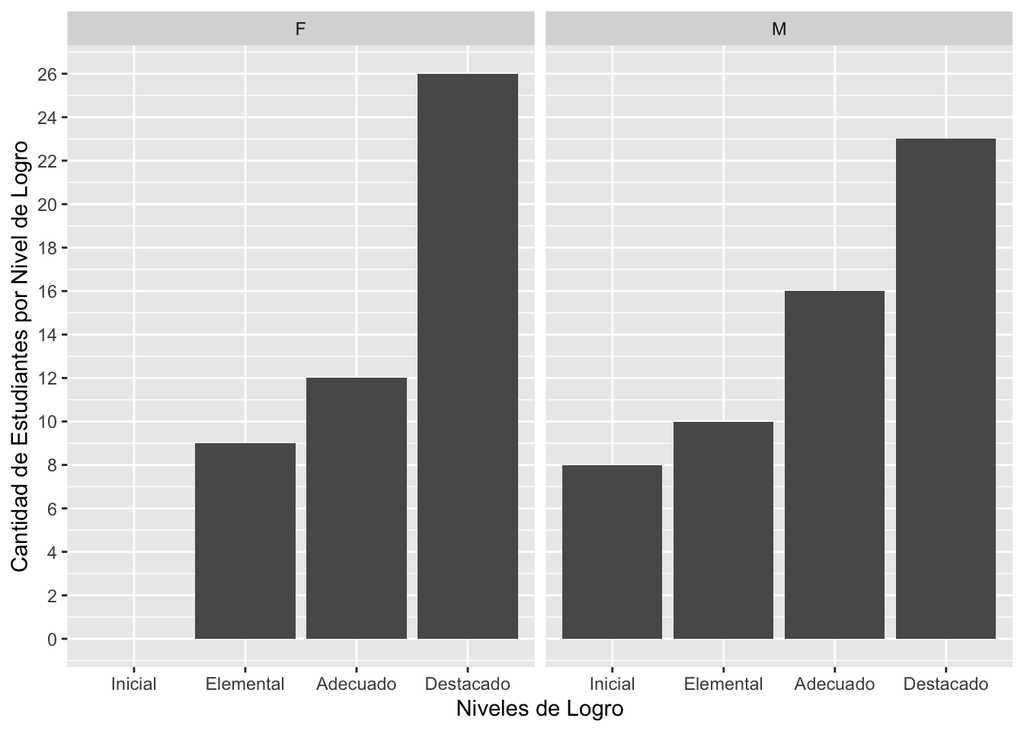

#### 0.3.3.8 Octavos Básicos

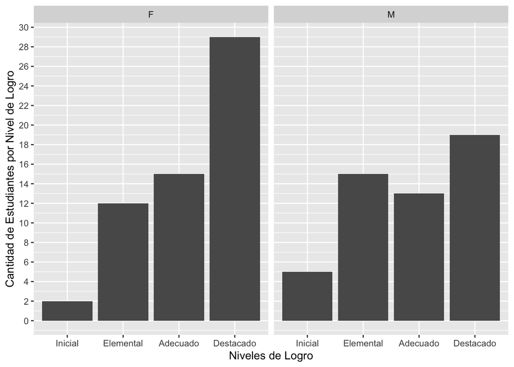

#### 0.3.3.9 Iº Medios

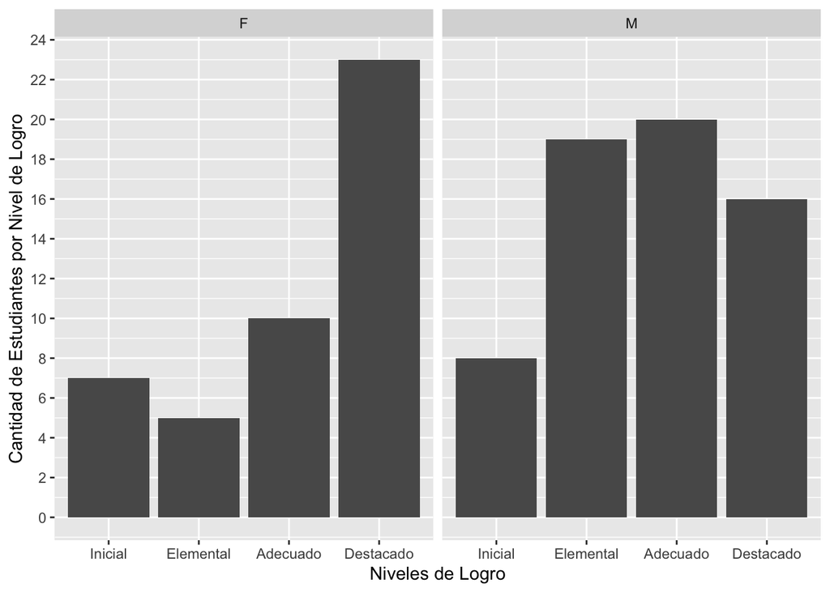

#### 0.3.3.10 IIº Medios

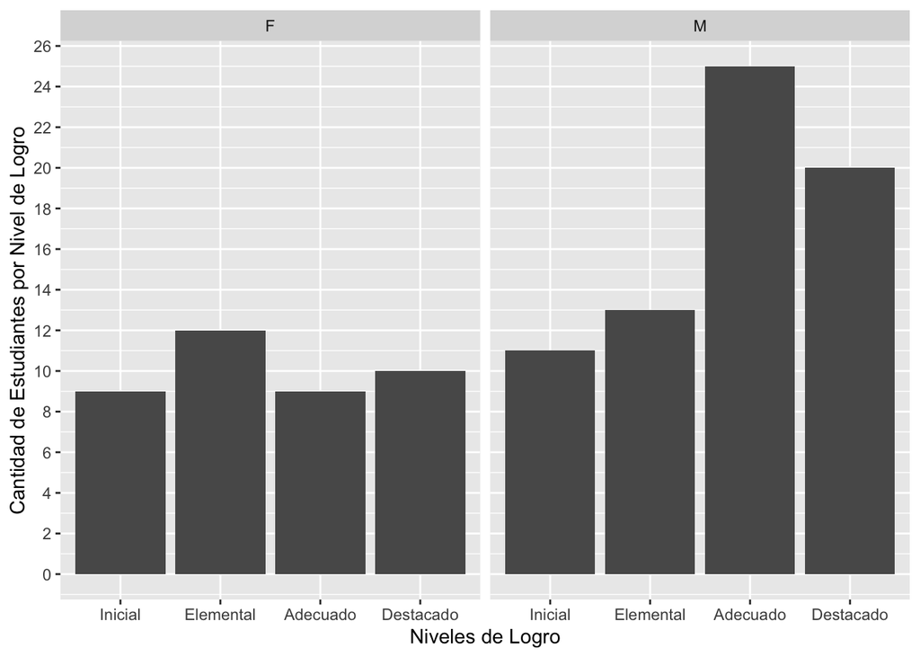

#### 0.3.3.11 IIIº Medios

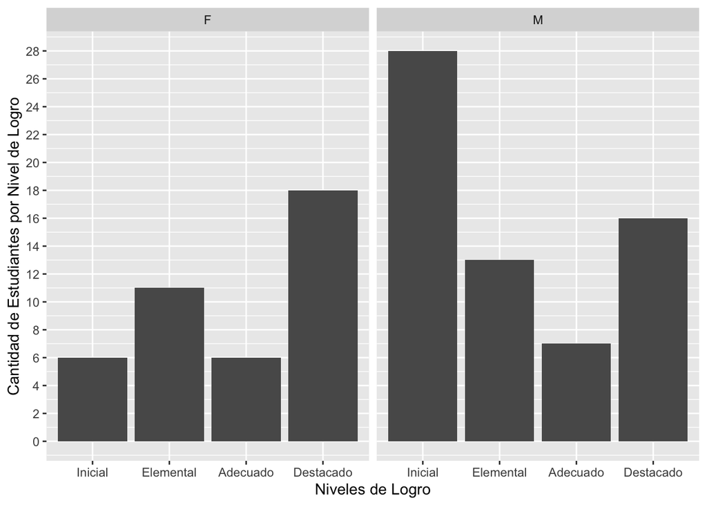

#### 0.3.3.12 IVº Medios

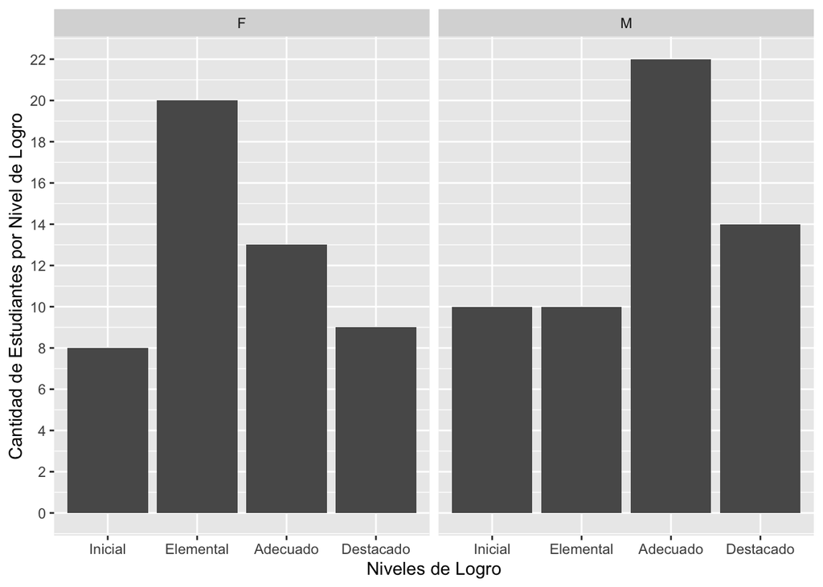

## 0.4 Resultados DIA - Ensayos PDT

### 0.4.1 Resultados DIA MAtemáticas OA año Anterior (3º - 5º Básico)

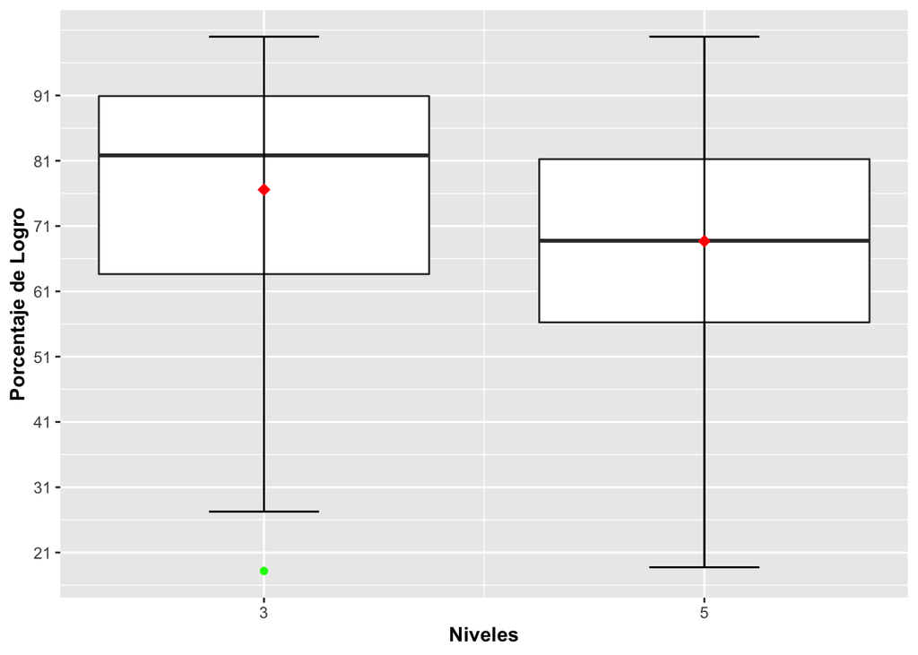

### 0.4.2 Resultados DIA Matemáticas OA año actual (3º - 5º básico)

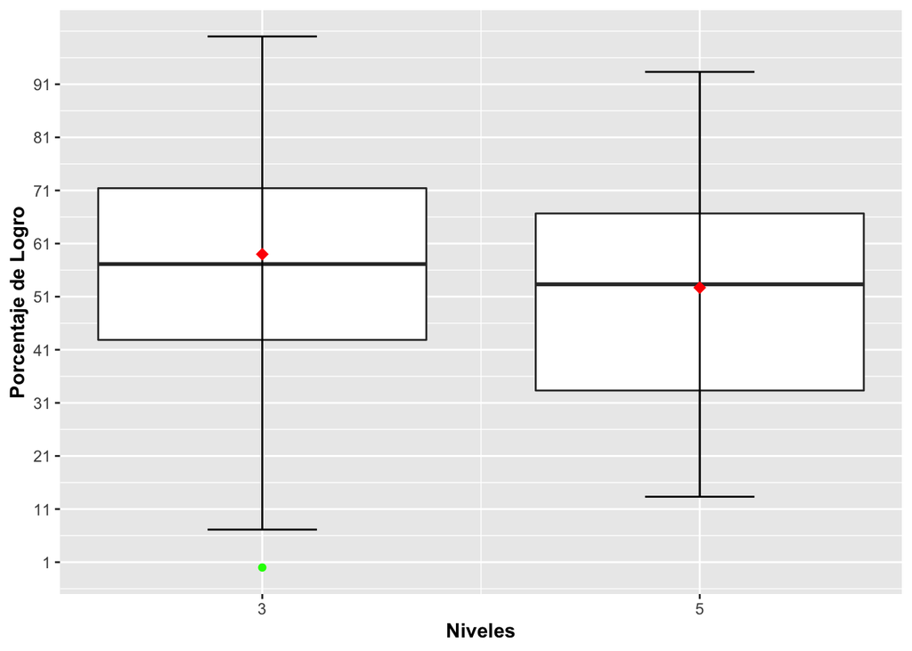

### 0.4.3 Resultados DIA Matemáticas (7º básico a IIº medio)

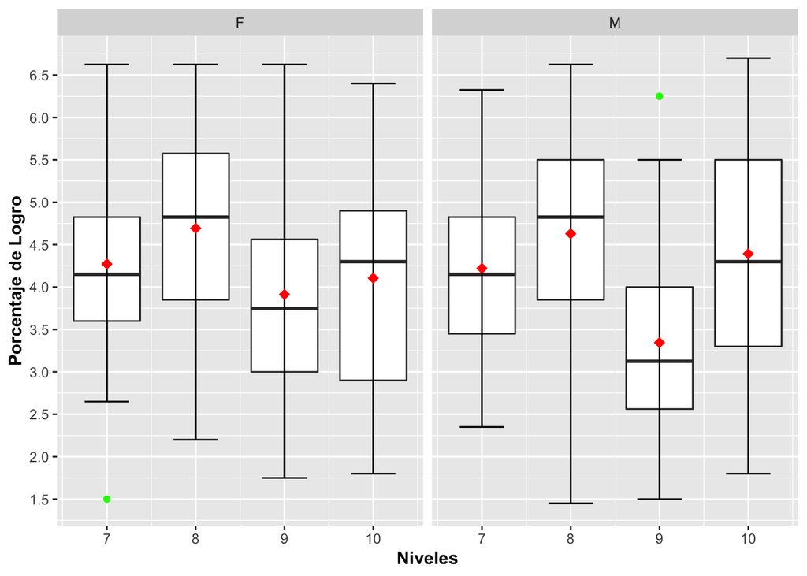

### 0.4.4 Resultados Ensayo PDT IIIº medio

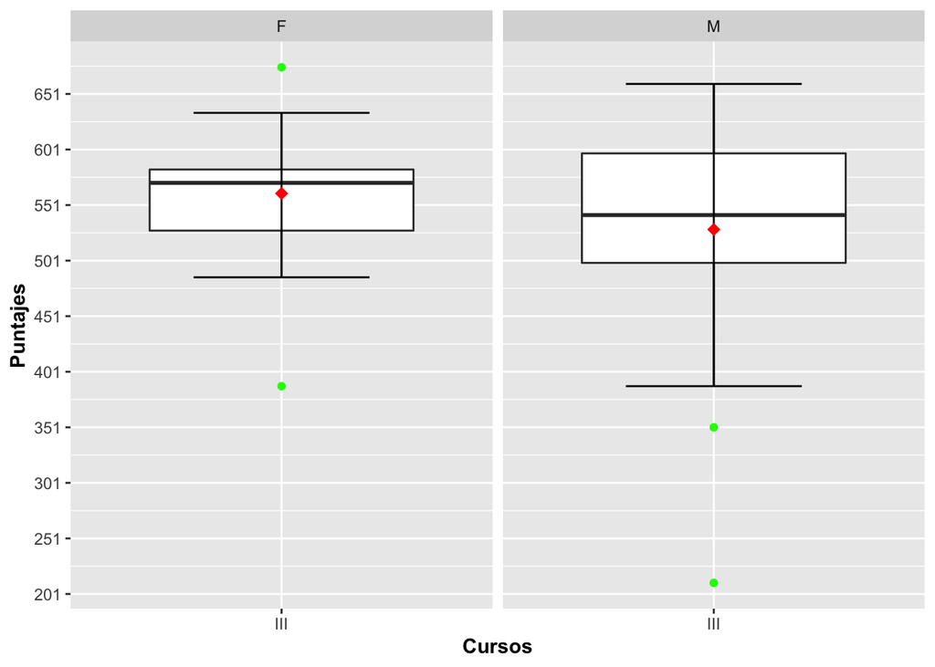

### 0.4.5 Resultados Ensayo PDT IVº medio (Julio)

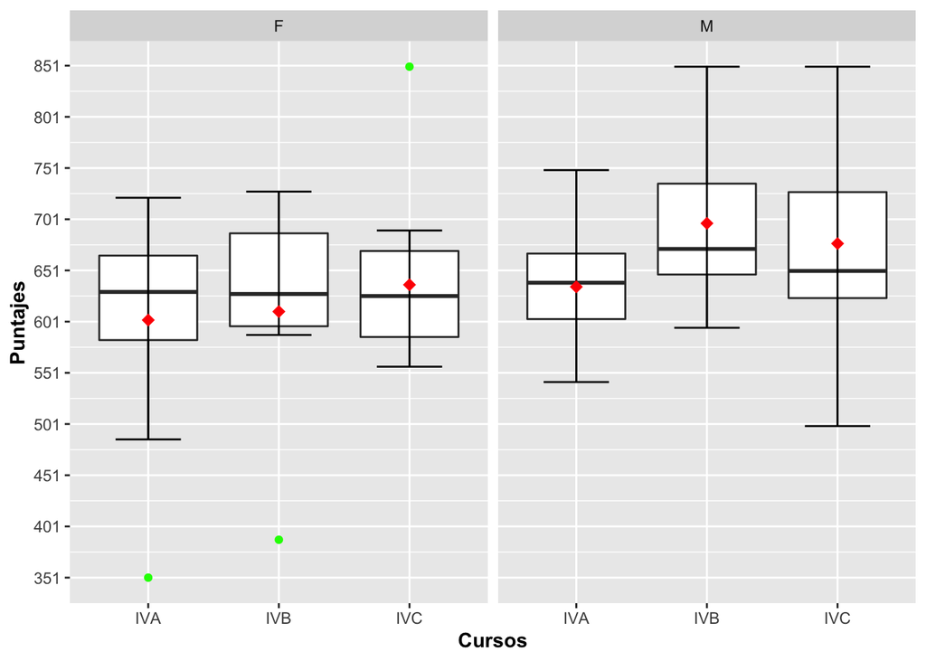

### 0.4.6 Resultados Ensayo PDT IVº medio (Agosto)

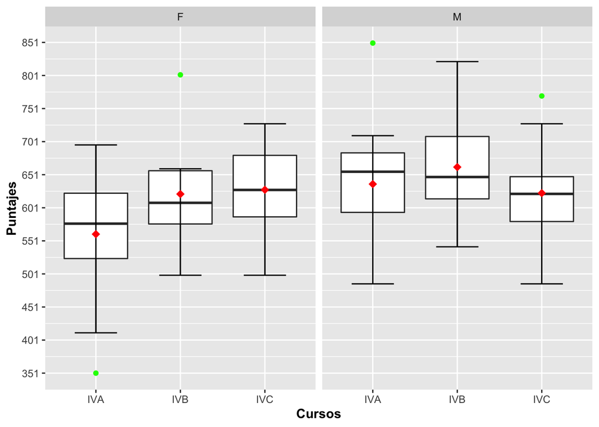

## 0.5 Plan de Evaluación II Semestre 2021

En la siguiente tabla se presentan los procedimientos e instrumentos declarados por el sector (1º básico en adelante) y la cantidad de veces que se repiten. Revisar lo declarado en el plan de evaluación considerando los siguientes criterios:

- ¿Hay claridad en el sector entre lo que es un procedimiento y su diferencia con el instrumento? **En el caso de dudas, revisar nuestro [Reglamento de Evaluación](https://www.colsanjavier.cl/files/documentos/REGLAMENTO%20INTERNO%20DE%20EVALUACIÓN%202021.%20%5Bv.%2030-04-2021%5D.pdf)**
- ¿Existe una diversidad de formas de evaluar o se limitan a la práctica recurrente de procedimientos e instrumentos utilizados en el sector? **Es necesario revisar si, en la implementación, hay diferencias metodológicas entre Pruebas, Test y Quizz o simplemente, estamos denominado de distinta manera a las clásicas pruebas de ejercicios.**
- **¿Lo declarado, permite dar cuenta de manera adecuada de los OA y de las metas definidas en el sector?**
- **Ajustar las metas que contengan verbos que son poco precisos a la hora de medir:** *Comprender, Reflexionar*. **Pero también, aquellas que contengan verbos que den cuenta de niveles básicos de aprendizaje:** *Identificar, Reconocer*. **Las metas de aprendizajes deben ser** *Medibles* **pero también** *Desafiantes*.

Por último, se agrega una nube de palabras que quiere reflejar el peso de los instrumentos/procedimientos declarados por el sector.

|  | word | freq |
| --- | --- | --- |
| prueba | prueba | 37 |
| test | test | 26 |
| quizz | quizz | 8 |
| informeavance | informeavance | 4 |
| investigación | investigación | 4 |

[interactive chart not shown]

### 0.5.1 Plan de Nivel

En el caso del **Plan de Nivel**, les solicito que cómo sector concuerden y plasmen en la planificación:

- En qué sesiones se evaluará el o los OA que se hacen responsables.
- El o los instrumentos que usarán para concretar esta evaluación.

Es importante que ustedes como jefes de sector hagan sequimiento de este proceso, ya que es el medio con el cual concretamos la formación integral. Pero, además, los resultados obtenidos, es lo que informamos a los estudiantes y sus familias en los distintos objetivos de aprendizajes asociados a las tres dimensiones de nuestro Mapa de Formación Integral.

## 0.6 Planificación de Clases

Durante las siguientes dos semanas pondremos énfasis en la planificación. Por lo que es importante avanzar toda la unidad 2 durante este tiempo. Para organizar la planificación les sugiero pensar un modelo de clases que considere la siguiente estructura. Esto con el objetivo de asegurar el aprendizaje de sus estudiantes:

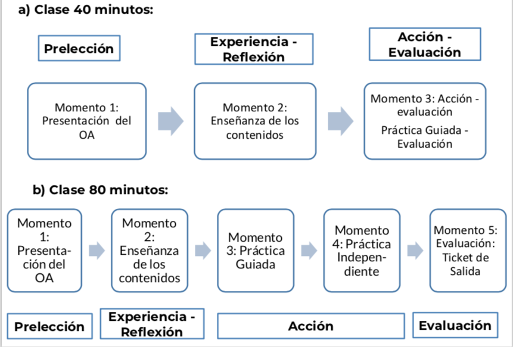

## 0.7 Metas de Aprendizajes

Se presentan las metas declaradas por el sector desde 1º básico a IIIº medio (al 15 de julio). Se dejó fuera cuarto medio por que está condicionado por el proceso PDT. Ajustar las metas considerando los siguientes criterios:

- ¿Están escritas de manera clara y precisa que permitan ser evaluada(medida)?: Ejemplo: *Resolver problemas que involucren potencias. Para esto, utilizan lo aprendido sobre potencias y extienden las propiedades al nuevo ámbito numérico, con extensión a base racional y exponente negativo" (Primero Medio)*
- **¿Contienen errores gramaticales:** **Redacción, Faltas de Ortografía** **?**
- ¿Se usan los verbos adecuado? Ejemplo: *“Describen y reconocen en las figuras 3D sus elementos…” (Tercero Básico)* o *“Comprender y aplicar ecuaciones…” (Octavo Básico)*. Priorizar verbos que engloben más que una secuencia de éstos
- **¿Dan cuenta de aprendizajes relevantes que deben adquirir mis estudiantes? ¿Es coherente con el plan de estudios?**
- ¿Las metas dan cuenta solo de “saberes” (aprendizajes curriculares) o de desempeños a realizar con lo aprendido? Ejemplo: *“Analizar diversas situaciones de organización de información mediante la construcción de tablas de frecuencia, gráficos y medidas de tendencia central”* ¿Esto debe ser una meta o es parte del proceso para llegar a una meta?
- **Revisar que en varios niveles, hay más de una meta por unidad. No queda claro esto si es por falta de comprensión de lo que es una meta o debido a los OA?** Ejemplo: 2º básico
- **En el caso de octavo básico falta la meta de la unidad 3**

### 0.7.1 Metas de Aprendizajes Primer Ciclo

| Nivel | Segunda Unidad | Tercera Unidad |
| --- | --- | --- |
| Primero Básico | Comprenderán que los números son parte de la vida y que los podemos utilizar para resolver distintas situaciones de la vida cotidiana. | Meta 1: Comprenderán que en su entorno pueden encontrar diversos objetos que forman figuras 3D y 2D. Al finalizar serán capaces de identificar diferencias, relacionar las figuras 3D y 2D y clasificar … |
| Segundo básico | Los estudiantes utilizarán gráficos de barra simple para interpretar datos de contexto cotidiano y complementar el proyecto de pueblos originarios, entregando información y datos relevantes de estos. | Utilizarán medidas estandarizadas y no estandarizadas para medir y crear figuras y cuerpos geométricos. |

### 0.7.2 Metas de Aprendizajes Segundo Ciclo

| Nivel | Segunda Unidad | Tercera Unidad |
| --- | --- | --- |
| Tercero básico | Describen y reconocen en las figuras 3D sus elementos , la red que la forma, las figuras 2D que la componen, a la vez, son capaces de cálcular perímetro de una figura, llegando a datos a través de sit… | Demostrarán que son capaces de resolver y crear ejercicios de problemas de planteo que involucren, ya sea multiplicar, dividir o las 4 operaciones básicas combinadas, llegando al resultado correcto y … |
| Cuarto básico | Describir trayectorias en el plano con dos o más cambios de desplazamiento; reconocer una figura 3D e integrar sus vistas e identificar, describir y comparar figuras 2D y sus elementos y, como éstos f… | Los estudiantes son capaces de medir longitud en centímetros, así como determinar el área de cuadrados y rectángulos, dadas las medidas de algunos de sus lados. Además, realizan cálculos que involucra… |
| Quinto básico | Diseñarán a partir de reglas y patrones numéricos para completar sucesiones. Modelar distintos movimientos de figuras en el plano, realizando tranformaciones isométricas en el primer cuadrante del pla… | Resuelven problemas con unidades de medida (mm, cm y m), transformando unidades de medidas de longitud, para calcular área de triángulos paralelogramos y trapecios. Calculan promedios de datos para re… |
| Sexto básico | Traducen de lenguaje natural a lenguaje algebraíco y viceversa. Expresando situaciones con expresiones algebraicas. Resuelven expresiones con variables o incógnitas, descubriendo el valor de una incóg… | Calculan y comprenden concepto de área de una superficie de cuerpos geomértricos o de sus redes. Son capaces de interpretar gráficos de barra dobles y circulares. Representan información en diagramas … |

### 0.7.3 Metas de Aprendizajes Tercer y Cuarto Ciclo (7º básico a IIIº medio)

En este caso, no se consideró cuarto medio porque su foco esta relevado a la prueba PDT.

| Nivel | Segunda Unidad | Tercera Unidad |
| --- | --- | --- |
| Séptimo básico | Aplicar lenguaje algebraico y resolución de ecuaciones e inecuaciones para resolver diversos problemas en contextos cotidianos y geométricos | Comprender y aplicar los conceptos de área y perímetro de figuras planas (círcunferencia, cuadriláteros, triángulos y polígonos) para resolver problemas diversos. Analizar diversas situaciones de orga… |
| Octavo básico | Comprender y aplicar ecuaciones, inecuaciones, función lineal y afín para solucionar situaciones problema de contextos cotidianos y geométricos. |  |
| Primero medio | Resolver problemas que involucren potencias. Para esto, utilizan lo aprendido sobre potencias y extienden las propiedades al nuevo ámbito numérico, con extensión a base racional y exponente negativo. | Analizar distribuciones de dos características de una población, construyendo tablas de doble entrada y nubes de puntos; hacen esto último para analizar las características de la población y ampliar l… |
| Segundo Medio | Reconocer y aplicar la función cuadratica y sus propiedades para dar respuesta a problemas de la vida cotidiana. | Utilizar permutaciones y la combinatoria sencilla para calcular probabilidades de eventos y resolver problemas. Aplicar las razones trigonométricas de seno, coseno y tangente en triángulos rectángulos… |
| Tercero Medio | Aplicar los teoremas de ángulos en la circunferencia en la resolución de problemas. Aplicar las ecuaciones de segundo grado, y sus propiedades en la resolución de problemas. | Formular y verificar conjeturas respecto de los cuerpos generados a partir de traslaciones o rotaciones de figuras planas, para aplicarlos en la resolución de problemas. |